# R function techniques

Kenny

Sunday, January 11, 2015

### writing a R file to perform

> making script

```r
x <- c(0.458, 1.6653, 0.83112) # data created and store in x

percent <- round(x * 100, digits = 1) # perform calculation and store in percent

result <- paste(percent, "%", sep = "") # make appearance and store in result

print(result) # display the result and then save it as .R file through Rstudio
```

```
## [1] "45.8%"  "166.5%" "83.1%"
```

### open a R file to perform calculation

```r
source('pastePercent.R') # run this code to run all the code written within and get result
```

```
## [1] "45.8%"  "166.5%" "83.1%"
```

```r
x # all objects in the file is created and ready to use
```

```
## [1] 0.45800 1.66530 0.83112
```

```r
percent
```

```
## [1]  45.8 166.5  83.1
```

```r
result
```

```
## [1] "45.8%"  "166.5%" "83.1%"
```

### from the script to function

```r
addPercent <- function(x){                          # assign data to x, and assign function to a nickname
  percent <- round(x * 100, digits = 1)             # calculation performed
  result <- paste(percent, "%", sep = "")           # format made
  return(result)                                    # in function display result = return(result)
}
```

> **structure of a function**
> 1. The keyword function always must be followed by parentheses – function().
> 2. Between the parentheses are the arguments to the function, in this case, x.
> 3. The braces, {}, can be seen as the walls of your function.
> 4. The return() statement is the back gate of your function. The object you put between the parentheses is returned from inside the function to your workspace. You can put only one object between the parentheses.
> 5. using addPercent <- function(x)… to help R find address to send numbers to for transformation. Now the function has a nice name and is ready to use.
> 6. If you want to control which type of object is given as an argument, you have to do so manually, in the body of the function.

### Using the function with new data

```r
new.numbers <- c(0.8223, 0.02487, 1.62, 0.4)
addPercent(new.numbers)
```

```
## [1] "82.2%" "2.5%"  "162%"  "40%"
```

### Playing with function objects

```r
ppaste <- addPercent # assign the function to a new nickname
ppaste  # useful for using function inside other functions
```

```
## function(x){                          # assign data to x, and assign function to a nickname
##   percent <- round(x * 100, digits = 1)             # calculation performed
##   result <- paste(percent, "%", sep = "")           # format made
##   return(result)                                    # in function display result = return(result)
## }
```

```r
addPercent
```

```
## function(x){                          # assign data to x, and assign function to a nickname
##   percent <- round(x * 100, digits = 1)             # calculation performed
##   result <- paste(percent, "%", sep = "")           # format made
##   return(result)                                    # in function display result = return(result)
## }
```

```r
ppaste(new.numbers)
```

```
## [1] "82.2%" "2.5%"  "162%"  "40%"
```

```r
?ppaste
```

```
## No documentation for 'ppaste' in specified packages and libraries:
## you could try '??ppaste'
```

> you will erase the function or data by giving the same name with different assignments. There’s no undo button in R, but your functions are safe in packages.

### Check objects you created and are ready to use

```r
ls() # let R tell you what objects available to you at the moment
```

```
## [1] "addPercent"  "new.numbers" "percent"     "ppaste"      "result"
## [6] "x"
```

### Reducing the number of lines

> print(function) = function with return(result)

```r
addPercentS <- function(x){
  percent <- round(x * 100, digits = 1)
  result <- paste(percent, "%", sep = "")
} # once this code is run, the new function object addPercentS is created and ready for use


print( addPercentS(new.numbers) )
```

```
## [1] "82.2%" "2.5%"  "162%"  "40%"
```

> return(result) is not necessary, paste() can display result too

```r
addPercentS <- function(x){
  percent <- round(x * 100, digits = 1)
  paste(percent, "%", sep = "")
}

addPercentS(new.numbers)
```

```
## [1] "82.2%" "2.5%"  "162%"  "40%"
```

> return() is useful if you want to test on type of data first and exit without running codes afterwards

```r
addPercent <- function(x){
  if( !is.numeric(x) ) return(NULL) # this is a powerful and self-regulate-help measures
  percent <- round(x * 100, digits = 1)
  paste(percent, "%", sep = "")
}
```

### Breaking the walls is a bad habit though working

> addPercent <- function(x) paste(round(x * 100, digits = 1), “%”, sep = “”)

### Understanding arguments in functions

> 1. Arguments are always named when you define the function. But when you call the function, you don’t have to specify the name of the argument if you give them in the order in which they appear in the argument list of a function.
> 2. Arguments can be optional, in which case you don’t have to specify a value for them.
> 3. Arguments can have a default value, which is used if you didn’t specify a value for that argument yourself.
> 4. Not only can you use as many arguments as you like — or as is feasible, at least — but **you can very easily pass arguments on to functions inside the body of your own function with the simply genius `dots` argument**.

### A slice difference in data can make the simple function look weak

```r
percentages <- c(58.23, 120.4, 33) # much unlike new.numbers
new.numbers
```

```
## [1] 0.82230 0.02487 1.62000 0.40000
```

```r
addPercent(percentages) # direct apply percentages will result unwanted outcome
```

```
## [1] "5823%"  "12040%" "3300%"
```

```r
addPercent(percentages/100) # transformation needed for percentage data, make it look like new.numbers
```

```
## [1] "58.2%"  "120.4%" "33%"
```

> the problem is this simple function cannot handle two different nature of data at the same time

### Adding the mult argument to deal with different data with different measures

```r
addPercentCom <- function(x, mult){  # add mult to specify and deal with the different types of data
  percent <- round(x * mult, digits = 1)
  paste(percent, "%", sep = "")
}
```

> now Let’s give mult a default value for data more likely to encounter

```r
addPercentCom <- function(x, mult = 100){ # now set default value of mult = 100
  percent <- round(x * mult, digits = 1)
  paste(percent, "%", sep = "")
}

addPercentCom(new.numbers) # as default, no need to specify mult = 100
```

```
## [1] "82.2%" "2.5%"  "162%"  "40%"
```

```r
percentages
```

```
## [1]  58.23 120.40  33.00
```

```r
addPercentCom(percentages, 1) # by order, 1 refers to mult = 1, specifically dealing with data like percentages
```

```
## [1] "58.2%"  "120.4%" "33%"
```

### dots can save a lot of spaces

```r
addPercentDot <- function(x, mult = 100, ...){     # dots here can refer to multi-arguments
  percent <- round(x * mult, ...)   # dots here can refer to some or all of them
  paste(percent, "%", sep = "")
}

addPercentDot(new.numbers, digits = 2) # replace dots with the argument needed here
```

```
## [1] "82.23%" "2.49%"  "162%"   "40%"
```

```r
addPercentDot(new.numbers)
```

```
## [1] "82%"  "2%"   "162%" "40%"
```

```r
addPercentD <- function(x, mult = 100, digits = 1){ # if refuse to use dots, make explicit is good too
  percent <- round(x * mult, digits = digits)
  paste(percent, "%", sep = "")
}
```

### Using functions as arguments

> you can easily assign the complete code of a function to a new object. In much the same way, you also can assign the function code to an argument. This opens up a complete new world of possibilities.

```r
addPercentFun <- function(x, mult = 100, FUN = round, ...){ # FUN = can be any function you want, the default FUN is round; '...' no need to spell out;

# !!!! mult = 100, as default value, used within FUN to recalcualte the data before running FUN
  percent <- FUN(x * mult, ...)  # "..." stand for one argument, and without default value
  paste(percent, "%", sep = "")
}

addPercentFun(new.numbers, FUN = signif, digits = 3) # choose signif for FUN, specify digits = 3 instead of "..." if you know
```

```
## [1] "82.2%" "2.49%" "162%"  "40%"
```

> I feel `...` can only represent one argument only  
> If you added the parentheses to round as FUN = round() or signif(), you would assign the result of a call to signif() instead of the function itself. R would interpret signif(), in that case, as a nested function, and that’s not what you want.

### Using anonymous functions within a function

```r
ls()
```

```
##  [1] "addPercent"    "addPercentCom" "addPercentD"   "addPercentDot"
##  [5] "addPercentFun" "addPercentS"   "new.numbers"   "percent"
##  [9] "percentages"   "ppaste"        "result"        "x"
```

```r
profits <- c(2100, 1430, 3580, 5230)  # set the data

rel.profit <- function(x) round(x / sum(x) * 100) # write a new function to calculate profit/sum percent

rel.profit(profits)
```

```
## [1] 17 12 29 42
```

```r
addPercentFun(profits,
                FUN = function(x) round(x / sum(x) * 100) ) # use addPercent func, make your own FUN =
```

```
## [1] "17%" "12%" "29%" "42%"
```

### local and global environment

> you work solely in the workspace. Every object you create ends up in this environment, which is called the global environment. The workspace — or global environment — is the universe of the R user where everything happens.

### Creating a test case

```r
x <- 1:5 # x here is in global environment
test <- function(x){  # x here is in the local environment of the function
  cat("This is x:", x)
  rm(x) # x in local environment has been removed
  cat("This is x after removing it:",x, "\n") # this code require x object, so R looks for x from global environment
}

test(5:1) # now 5:1 is data within local environment; outcome is 1:5, as x <- 1:5 in global env
```

```
## This is x: 5 4 3 2 1This is x after removing it: 1 2 3 4 5
```

```r
x <- 1:5 # x here is in global environment
test <- function(x){  # x here is in the local environment of the function
  cat("This is x:", x, "\n") # "\n" is to seperate output
  rm(x) # x in local environment has been removed
  cat("This is x after removing it:",x,"\n") # this code require x object, so R looks for x from global environment
}

test(5:1)
```

```
## This is x: 5 4 3 2 1
## This is x after removing it: 1 2 3 4 5
```

### global and local env

> the whole concept behind R strongly opposes using global variables used in different functions. As a functional programming language, one of the main ideas of R is that the outcome of a function should not be dependent on anything but the values for the arguments of that function.

```r
calculate.eff <- function(x, y, control){
  min.base <- function(z) z - mean(control)  # min.base() as internal function will be removed at the end of running calculate.eff()
  min.base(x) / min.base(y)
}

getwd()
```

```
## [1] "C:/Users/Natusme/Desktop/TechniqueR/R primer"
```

> global and local env path:

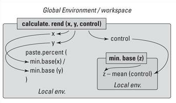

```r
half <- c(2.23, 3.23, 1.48)
full <- c(4.85, 4.95, 4.12)
nothing <- c(0.14, 0.18, 0.56, 0.23)
calculate.eff(half, full, nothing)
```

```
## [1] 0.4270093 0.6318887 0.3129473
```

### Dispatching to a Method

> We want to cover one more thing about functions, because you need it to understand how one function can give a different result based on the type of value you give the arguments. R has a genius system, called the generic function system, that allows you to call different functions using the same name.

> Functions that don’t do much other than passing on objects to the right function are called generic functions. In this example, **print() is a generic function**. The functions that **do the actual work are called methods**. So, **every method is a function, but not every function is a method**.

```r
print # show what generic function look like inside
```

```
## function (x, ...)
## UseMethod("print")
## <bytecode: 0x0000000007dbffc8>
## <environment: namespace:base>
```

```r
# the last two codes only for developers
```

> How on earth can that one line of code in the print() function do so many complex things like printing vectors, data frames, and lists all in a different way? The answer is contained in the UseMethod() function, which is the central function in the generic function system of R. **All UseMethod() does is tell R to move along and look for a function that can deal with the type of object that is given as the argument x**.

> **R does that by looking through the complete set of functions in search of another function that starts with print followed by a dot and then the name of the object type**

```r
head(methods(print))
```

```
## [1] "print.acf"     "print.AES"     "print.anova"   "print.aov"
## [5] "print.aovlist" "print.ar"
```

```r
small.one <- data.frame(a = 1:2, b = 2:1)
print.data.frame(small.one)
```

```
##   a b
## 1 1 2
## 2 2 1
```

```r
print(small.one)
```

```
##   a b
## 1 1 2
## 2 2 1
```

```r
print.default(small.one) # this function intend to produce list
```

```
## $a
## [1] 1 2
##
## $b
## [1] 2 1
##
## attr(,"class")
## [1] "data.frame"
```

### make a S3 function

> Adapting the addPercent function for character vector

```r
addPercent.character <- function(x){
  paste(x,"%",sep="")
}
```

> the addPercent function for numeric vector

```r
addPercent.numeric <- function(x, mult = 100, FUN = round, ...){
  percent <- FUN(x * mult, ...)
  paste(percent, "%", sep = "")
}
```

> make the S3 function

```r
addPercent <- function(x,...){
  UseMethod("addPercent")
}
```

> now addPercent function can deal with all different data type, R automatically select the right method function for the appropriate data

```r
addPercent(new.numbers, FUN = floor)
```

```
## [1] "82%"  "2%"   "162%" "40%"
```

```r
addPercent(letters[1:6])
```

```
## [1] "a%" "b%" "c%" "d%" "e%" "f%"
```

> Adding a message to avoid dataframe

```r
# addPercent(small.one) # Gives error on purpose
# in console it will produce:
### Error in UseMethod(“addPercent”) :
### no applicable method for ‘addPercent’ applied to an object of class “data.frame”

addPercent.default <- function(x){
  cat('You should try a numeric or character vector.\n')
}

addPercent(small.one)
```

```
## You should try a numeric or character vector.
```

### find out all method function of a generic function

```r
apropos("addPercent\\..")
```

```
## [1] "addPercent.character" "addPercent.default"   "addPercent.numeric"
```

```r
methods(addPercent)
```

```
## [1] addPercent.character addPercent.default   addPercent.numeric
```

### see the source code of function

```r
library(ggplot2)
sd
```

```
## function (x, na.rm = FALSE)
## sqrt(var(if (is.vector(x)) x else as.double(x), na.rm = na.rm))
## <bytecode: 0x00000000077bfcc0>
## <environment: namespace:stats>
```

```r
boxplot
```

```
## function (x, ...)
## UseMethod("boxplot")
## <bytecode: 0x0000000007478188>
## <environment: namespace:graphics>
```

```r
methods(boxplot)
```

```
## [1] boxplot.default  boxplot.formula* boxplot.matrix
##
##    Non-visible functions are asterisked
```

```r
boxplot.matrix   # See source for non-hidden method
```

```
## function (x, use.cols = TRUE, ...)
## {
##     groups <- if (use.cols)
##         split(x, rep.int(1L:ncol(x), rep.int(nrow(x), ncol(x))))
##     else split(x, seq(nrow(x)))
##     if (length(nam <- dimnames(x)[[1 + use.cols]]))
##         names(groups) <- nam
##     invisible(boxplot(groups, ...))
## }
## <bytecode: 0x0000000008c53d18>
## <environment: namespace:graphics>
```

```r
# boxplot.formula  # Try to see source for hidden method, but couldn't

getAnywhere("boxplot.formula")
```

```
## A single object matching 'boxplot.formula' was found
## It was found in the following places
##   registered S3 method for boxplot from namespace graphics
##   namespace:graphics
## with value
##
## function (formula, data = NULL, ..., subset, na.action = NULL)
## {
##     if (missing(formula) || (length(formula) != 3L))
##         stop("'formula' missing or incorrect")
##     m <- match.call(expand.dots = FALSE)
##     if (is.matrix(eval(m$data, parent.frame())))
##         m$data <- as.data.frame(data)
##     m$... <- NULL
##     m$na.action <- na.action
##     require(stats, quietly = TRUE)
##     m[[1L]] <- quote(stats::model.frame)
##     mf <- eval(m, parent.frame())
##     response <- attr(attr(mf, "terms"), "response")
##     boxplot(split(mf[[response]], mf[-response]), ...)
## }
## <bytecode: 0x0000000009132fa8>
## <environment: namespace:graphics>
```

```r
library(lme4)
refit           # Try to show the source for the refit function
```

```
## function (object, newresp, ...)
## UseMethod("refit")
## <environment: namespace:lme4>
```

```r
showMethods("refit")     # Show available methods
```

```
##
## Function "refit":
##  <not an S4 generic function>
```

```r
# List the source code for refit for class type numeric
findMethods("refit", classes="numeric")
```

```
## list()
```